# AllLifeBankCustomerSegmentation

#### Problem Definition

- AllLife Bank wants to focus on its credit card customer base in the next financial year. They have been advised by their marketing research team, that the penetration in the market can be improved. Based on this input, the Marketing team proposes to run personalized campaigns to target new customers as well as upsell to existing customers. Another insight from the market research was that the customers perceive the support services of the back poorly. Based on this, the Operations team wants to upgrade the service delivery model, to ensure that customer queries are resolved faster. Head of Marketing and Head of Delivery both decide to reach out to the Data Science team for help

#### Objective

- As a Data scientist at AllLife Bank, I would need to identify different segments in the existing customers based on their spending patterns as well as past interaction with the bank, using clustering algorithms, and provide recommendations to the bank on how to better market to and service these customers.

###### Insight after reading the backround and context

- My understanding after reading data dictionary, to add new customers, insight into these two feaures 'Avg_Credit_Limit' & 'Total_Credit_Cards' are vital. At the same time to retain existing customers and upsell products to existing customers focus on these three featurea are equally important - 'Total_visits_bank', 'Total_visits_online', 'Total_calls_made. The less time customers spend on calls with the bank support staff is very important. This not only helps to get positive feedback from the existing customers but also bank get good customer statisfaction rating that further helps to penatrate into new markets.

#### Brief Approach

- I have used feature engineering techniques like duplicate items identification, outlier detection and how to deal with them.
- I'm going to use both K-means & Hierarchical Clustering (euclidean & Manhatten) then built Cluster Profiling, box plots.
- As a final step I offered my conclusions and recommendations.

#### Loading all required libraries to perform Assignment.

```python
# this will help in making the Python code more structured automatically (good coding practice)
%load_ext nb_black

# Libraries to help with reading and manipulating data
import numpy as np
import pandas as pd

# Libraries to help with data visualization
import matplotlib.pyplot as plt
import seaborn as sns

sns.set_theme()

# Removes the limit for the number of displayed columns
pd.set_option("display.max_columns", None)
# Sets the limit for the number of displayed rows
pd.set_option("display.max_rows", 200)

# to scale the data using z-score
from sklearn.preprocessing import StandardScaler

# to compute distances
from scipy.spatial.distance import cdist

# to perform k-means clustering and compute silhouette scores
from sklearn.cluster import KMeans
from sklearn.metrics import silhouette_score

# to visualize the elbow curve and silhouette scores
from yellowbrick.cluster import KElbowVisualizer, SilhouetteVisualizer

# to compute distances
from scipy.spatial.distance import pdist

# to perform hierarchical clustering, compute cophenetic correlation, and create dendrograms
from sklearn.cluster import AgglomerativeClustering
from scipy.cluster.hierarchy import dendrogram, linkage, cophenet

# To supress warnings
import warnings

warnings.filterwarnings("ignore")
```

##### Load and overview the dataset

```python
data = pd.read_excel("CreditCardCustomerData.xlsx", sheet_name="Sheet1")
```

```python
data.shape
```

```
(660, 7)
```

```python
data.info()
```

```
<class 'pandas.core.frame.DataFrame'>
RangeIndex: 660 entries, 0 to 659
Data columns (total 7 columns):
 #   Column               Non-Null Count  Dtype
---  ------               --------------  -----
 0   Sl_No                660 non-null    int64
 1   Customer Key         660 non-null    int64
 2   Avg_Credit_Limit     660 non-null    int64
 3   Total_Credit_Cards   660 non-null    int64
 4   Total_visits_bank    660 non-null    int64
 5   Total_visits_online  660 non-null    int64
 6   Total_calls_made     660 non-null    int64
dtypes: int64(7)
memory usage: 36.2 KB
```

- There are 660 records in the data set.
- All are numiral columns in the data set.

```python
# looking top 5 rows
data.head()
```

|  | Sl_No | Customer Key | Avg_Credit_Limit | Total_Credit_Cards | Total_visits_bank | Total_visits_online | Total_calls_made |
| --- | --- | --- | --- | --- | --- | --- | --- |
| 0 | 1 | 87073 | 100000 | 2 | 1 | 1 | 0 |
| 1 | 2 | 38414 | 50000 | 3 | 0 | 10 | 9 |
| 2 | 3 | 17341 | 50000 | 7 | 1 | 3 | 4 |
| 3 | 4 | 40496 | 30000 | 5 | 1 | 1 | 4 |
| 4 | 5 | 47437 | 100000 | 6 | 0 | 12 | 3 |

```python
# taking copy of the data set to do further analysis
df = data.copy()
```

```python
# fixing column names
df.columns = [c.replace(" ", "_") for c in df.columns]
```

```python
df.info()
```

```
<class 'pandas.core.frame.DataFrame'>
RangeIndex: 660 entries, 0 to 659
Data columns (total 7 columns):
 #   Column               Non-Null Count  Dtype
---  ------               --------------  -----
 0   Sl_No                660 non-null    int64
 1   Customer_Key         660 non-null    int64
 2   Avg_Credit_Limit     660 non-null    int64
 3   Total_Credit_Cards   660 non-null    int64
 4   Total_visits_bank    660 non-null    int64
 5   Total_visits_online  660 non-null    int64
 6   Total_calls_made     660 non-null    int64
dtypes: int64(7)
memory usage: 36.2 KB
```

- There are no missing values in the data.
- How ever I read 'FAQ' and learned that there are few customer_key were repeated. Let me look into.

##### To check duplicate records in the data set

```python
# checking duplicate rows in the data set
data.duplicated().sum()
```

```
0
```

- No duplicate records found

```python
df[df.duplicated(["Customer_Key"], keep=False)].sort_values("Customer_Key")
```

|  | Sl_No | Customer_Key | Avg_Credit_Limit | Total_Credit_Cards | Total_visits_bank | Total_visits_online | Total_calls_made |
| --- | --- | --- | --- | --- | --- | --- | --- |
| 48 | 49 | 37252 | 6000 | 4 | 0 | 2 | 8 |
| 432 | 433 | 37252 | 59000 | 6 | 2 | 1 | 2 |
| 4 | 5 | 47437 | 100000 | 6 | 0 | 12 | 3 |
| 332 | 333 | 47437 | 17000 | 7 | 3 | 1 | 0 |
| 411 | 412 | 50706 | 44000 | 4 | 5 | 0 | 2 |
| 541 | 542 | 50706 | 60000 | 7 | 5 | 2 | 2 |
| 391 | 392 | 96929 | 13000 | 4 | 5 | 0 | 0 |
| 398 | 399 | 96929 | 67000 | 6 | 2 | 2 | 2 |
| 104 | 105 | 97935 | 17000 | 2 | 1 | 2 | 10 |
| 632 | 633 | 97935 | 187000 | 7 | 1 | 7 | 0 |

- There are 5 rows are having same 'Customer_Key' id twice. This could be due to either data anamoloy or customers tracked differently based on certain conditions or profiles. We do not have enough data to validate either one. Rather than dropping one of the row, I would like to keep both of them for these 5 rows.
- Since Customer_Key is not needed to segment customers, dropping the column.

###### Sl_No and Customer_Key are not needed for analysis, I'm going to drop this column.

```python
df.drop(["Sl_No", "Customer_Key"], axis=1, inplace=True)
```

```python
# checking data set after 2 colummns dropped.
df.info(0)
```

```
<class 'pandas.core.frame.DataFrame'>
RangeIndex: 660 entries, 0 to 659
Data columns (total 5 columns):
 #   Column               Non-Null Count  Dtype
---  ------               --------------  -----
 0   Avg_Credit_Limit     660 non-null    int64
 1   Total_Credit_Cards   660 non-null    int64
 2   Total_visits_bank    660 non-null    int64
 3   Total_visits_online  660 non-null    int64
 4   Total_calls_made     660 non-null    int64
dtypes: int64(5)
memory usage: 25.9 KB
```

- All are numerical columns.

###### Checking the summary of the data

```python
df.describe().T
```

|  | count | mean | std | min | 25% | 50% | 75% | max |
| --- | --- | --- | --- | --- | --- | --- | --- | --- |
| Avg_Credit_Limit | 660.0 | 34574.242424 | 37625.487804 | 3000.0 | 10000.0 | 18000.0 | 48000.0 | 200000.0 |
| Total_Credit_Cards | 660.0 | 4.706061 | 2.167835 | 1.0 | 3.0 | 5.0 | 6.0 | 10.0 |
| Total_visits_bank | 660.0 | 2.403030 | 1.631813 | 0.0 | 1.0 | 2.0 | 4.0 | 5.0 |
| Total_visits_online | 660.0 | 2.606061 | 2.935724 | 0.0 | 1.0 | 2.0 | 4.0 | 15.0 |
| Total_calls_made | 660.0 | 3.583333 | 2.865317 | 0.0 | 1.0 | 3.0 | 5.0 | 10.0 |

#### Observations -

- About 75 % of Customer's 'Avg_Credit_Limit' is around 48000 where as the max seems 200000. It looks like it is an outlier. I would leave it there than removing it.
- 'Avg_Credit_Limit' mean value (34574) is much higher than median value (18000). It is positively skewed.
- 50 % (Median) of the customers holding 5 credit cards which is almost matching with mean. The max credit cards holding is 10
- Noticed same with these three features - Total_visits_bank, Total_visits_online and Total_calls_made Mean and mdeian are almost same. The max for Total_visits_online is 15 and for Total_calls_made is 10.

```python
# Trying to see if any customer who do not make call at all.
df[
    (df.Total_visits_bank == 0)
    & (df.Total_visits_online == 0)
    & (df.Total_calls_made == 0)
]
```

|  | Avg_Credit_Limit | Total_Credit_Cards | Total_visits_bank | Total_visits_online | Total_calls_made |
| --- | --- | --- | --- | --- | --- |

```python
df[(df.Total_visits_bank == 0)].describe()
```

|  | Avg_Credit_Limit | Total_Credit_Cards | Total_visits_bank | Total_visits_online | Total_calls_made |
| --- | --- | --- | --- | --- | --- |
| count | 100.000000 | 100.000000 | 100.0 | 100.000000 | 100.000000 |
| mean | 39150.000000 | 3.540000 | 0.0 | 5.030000 | 5.820000 |
| std | 56004.035749 | 2.698372 | 0.0 | 3.616614 | 3.085908 |
| min | 3000.000000 | 1.000000 | 0.0 | 1.000000 | 0.000000 |
| 25% | 9000.000000 | 2.000000 | 0.0 | 3.000000 | 4.000000 |
| 50% | 14000.000000 | 3.000000 | 0.0 | 4.000000 | 6.000000 |
| 75% | 20000.000000 | 4.000000 | 0.0 | 5.000000 | 8.000000 |
| max | 200000.000000 | 10.000000 | 0.0 | 15.000000 | 10.000000 |

- Customer who do not visit bank , the mean spending is around 39K and visit online 5 times and making calls 6 times per year.

```python
df[(df.Total_visits_online == 0)].describe()
```

|  | Avg_Credit_Limit | Total_Credit_Cards | Total_visits_bank | Total_visits_online | Total_calls_made |
| --- | --- | --- | --- | --- | --- |
| count | 144.000000 | 144.000000 | 144.000000 | 144.0 | 144.000000 |
| mean | 35131.944444 | 5.534722 | 3.506944 | 0.0 | 2.069444 |
| std | 22971.324943 | 1.211329 | 1.176676 | 0.0 | 1.475453 |
| min | 5000.000000 | 4.000000 | 2.000000 | 0.0 | 0.000000 |
| 25% | 13750.000000 | 4.000000 | 2.000000 | 0.0 | 1.000000 |
| 50% | 35000.000000 | 6.000000 | 3.500000 | 0.0 | 2.000000 |
| 75% | 56000.000000 | 7.000000 | 5.000000 | 0.0 | 3.000000 |
| max | 75000.000000 | 7.000000 | 5.000000 | 0.0 | 4.000000 |

- Customer who do not visit online , the median spending is around 35K and mean visit bank 3.5 times and made calls around 2 times.

```python
df[(df.Total_calls_made == 0)].describe()
```

|  | Avg_Credit_Limit | Total_Credit_Cards | Total_visits_bank | Total_visits_online | Total_calls_made |
| --- | --- | --- | --- | --- | --- |
| count | 97.000000 | 97.000000 | 97.000000 | 97.000000 | 97.0 |
| mean | 54536.082474 | 5.979381 | 2.989691 | 2.587629 | 0.0 |
| std | 50142.725847 | 1.707699 | 1.510345 | 4.094591 | 0.0 |
| min | 6000.000000 | 2.000000 | 0.000000 | 0.000000 | 0.0 |
| 25% | 16000.000000 | 5.000000 | 2.000000 | 0.000000 | 0.0 |
| 50% | 41000.000000 | 6.000000 | 3.000000 | 1.000000 | 0.0 |
| 75% | 70000.000000 | 7.000000 | 4.000000 | 2.000000 | 0.0 |
| max | 200000.000000 | 10.000000 | 5.000000 | 15.000000 | 0.0 |

- Customer who do not make calls , the mean spending is around 54k and mean visit bank 3 times and visit online also 2.5 times.

### EDA

##### Univerate Analysis

```python
# function to plot a boxplot and a histogram along the same scale.


def histogram_boxplot(data, feature, figsize=(12, 7), kde=False, bins=None):
    """
    Boxplot and histogram combined

    data: dataframe
    feature: dataframe column
    figsize: size of figure (default (12,7))
    kde: whether to the show density curve (default False)
    bins: number of bins for histogram (default None)
    """
    f2, (ax_box2, ax_hist2) = plt.subplots(
        nrows=2,  # Number of rows of the subplot grid= 2
        sharex=True,  # x-axis will be shared among all subplots
        gridspec_kw={"height_ratios": (0.25, 0.75)},
        figsize=figsize,
    )  # creating the 2 subplots
    sns.boxplot(
        data=data, x=feature, ax=ax_box2, showmeans=True, color="violet"
    )  # boxplot will be created and a star will indicate the mean value of the column
    sns.histplot(
        data=data, x=feature, kde=kde, ax=ax_hist2, bins=bins, palette="winter"
    ) if bins else sns.histplot(
        data=data, x=feature, kde=kde, ax=ax_hist2
    )  # For histogram
    ax_hist2.axvline(
        data[feature].mean(), color="green", linestyle="--"
    )  # Add mean to the histogram
    ax_hist2.axvline(
        data[feature].median(), color="black", linestyle="-"
    )  # Add median to the histogram
```

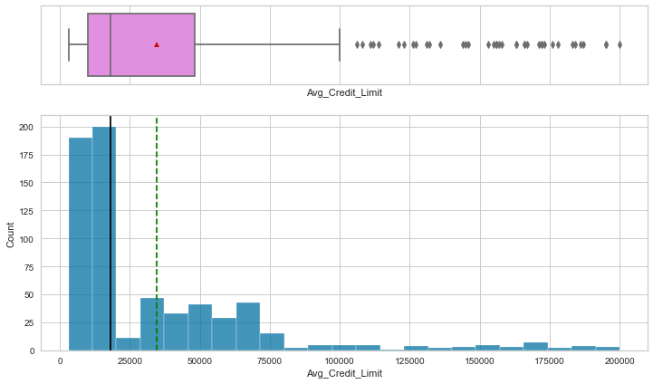

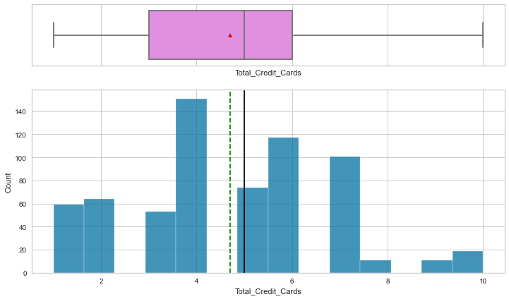

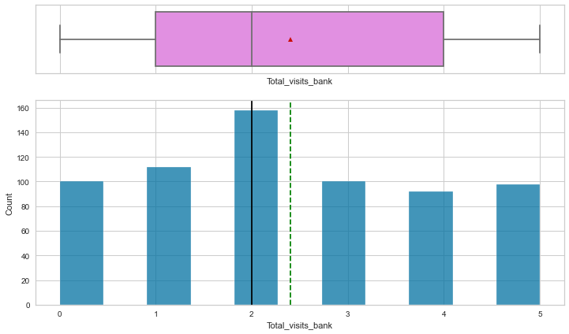

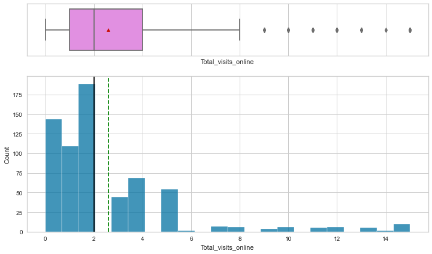

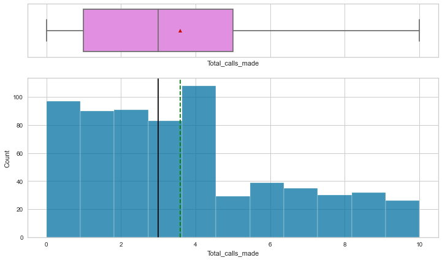

```python
# selecting numerical columns
num_col = df.select_dtypes(include=np.number).columns.tolist()

for item in num_col:
    histogram_boxplot(df, item)
```

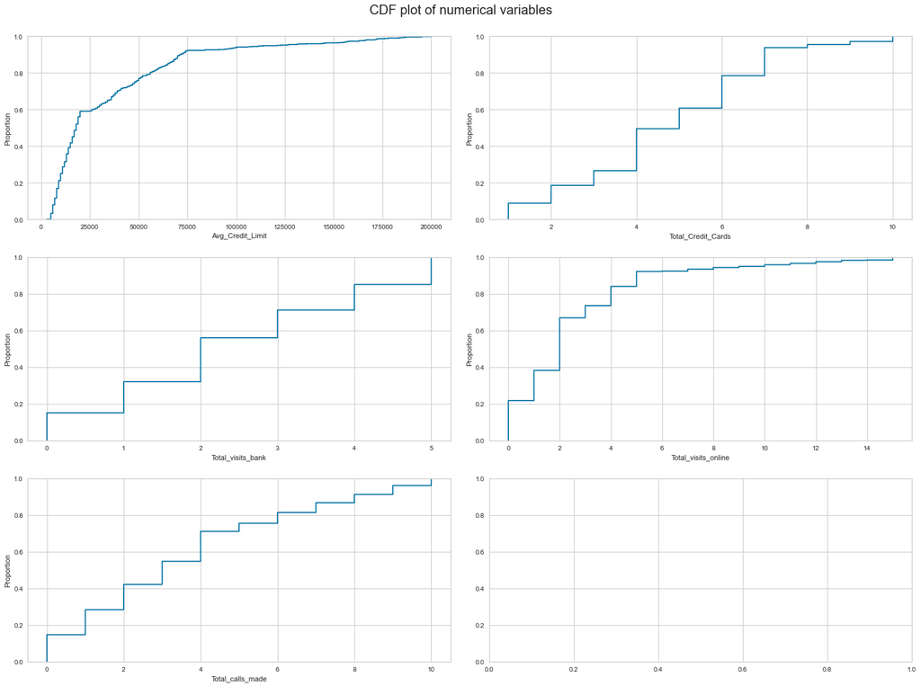

```python
fig, axes = plt.subplots(3, 2, figsize=(20, 15))
fig.suptitle("CDF plot of numerical variables", fontsize=20)
counter = 0
for ii in range(3):
    sns.ecdfplot(ax=axes[ii][0], x=df[num_col[counter]])
    counter = counter + 1
    if counter != 5:
        sns.ecdfplot(ax=axes[ii][1], x=df[num_col[counter]])
        counter = counter + 1
    else:
        pass

fig.tight_layout(pad=2.0)
```

##### Observations

```python
# function to create labeled barplots


def labeled_barplot(data, feature, perc=False, n=None):
    """
    Barplot with percentage at the top

    data: dataframe
    feature: dataframe column
    perc: whether to display percentages instead of count (default is False)
    n: displays the top n category levels (default is None, i.e., display all levels)
    """

    total = len(data[feature])  # length of the column
    count = data[feature].nunique()
    if n is None:
        plt.figure(figsize=(count + 1, 5))
    else:
        plt.figure(figsize=(n + 1, 5))

    plt.xticks(rotation=90, fontsize=15)
    ax = sns.countplot(
        data=data,
        x=feature,
        palette="Paired",
        order=data[feature].value_counts().index[:n].sort_values(),
    )

    for p in ax.patches:
        if perc:
            label = "{:.1f}%".format(
                100 * p.get_height() / total
            )  # percentage of each class of the category
        else:
            label = p.get_height()  # count of each level of the category

        x = p.get_x() + p.get_width() / 2  # width of the plot
        y = p.get_height()  # height of the plot

        ax.annotate(
            label,
            (x, y),
            ha="center",
            va="center",
            size=12,
            xytext=(0, 5),
            textcoords="offset points",
        )  # annotate the percentage

    plt.show()  # show the plot
```

##### Barplot with Avg_Credit_Limit

[figure not shown]

```python
# explore Avg_Credit_Limit further
labeled_barplot(df, "Avg_Credit_Limit", perc=True)
```

- Few outliers in this features. Most of them holding below 75K.

##### Barplot with Total_Credit_Cards

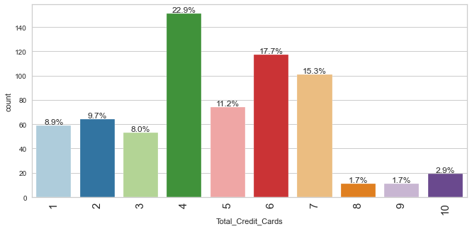

```python
# let's explore total_credit_cards further
labeled_barplot(df, "Total_Credit_Cards", perc=True)
```

##### Barplot with Total_visits_bank

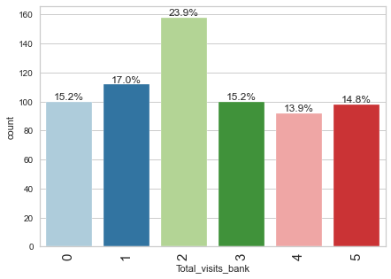

```python
# let's explore discounts further
labeled_barplot(df, "Total_visits_bank", perc=True)
```

##### Observations

- 45% of customers visited bank 3 to 5 times per year. It shows some customers like to visit bank.
- May be a good idea to discuss new products with these customers to increase upsell. Also need to see if they have any persistent issues.

##### Barplot with Total_visits_online

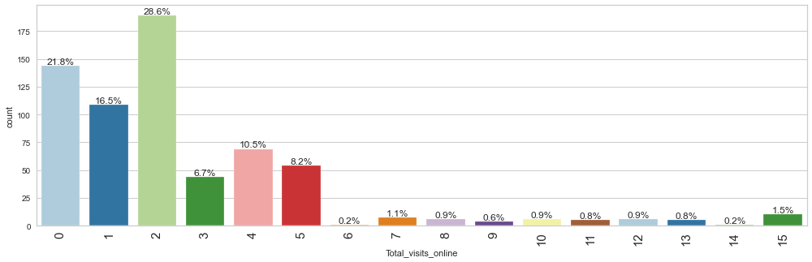

```python
# let's explore discounts further
labeled_barplot(df, "Total_visits_online", perc=True)
```

##### Observations

- 30% of customers visited bank online more than 3 times in a year time.
- Where as about 70% of them visited 2 times per year.
- May need to find what is the reason that 30 % customers visting more often, this may give bank a lead to find if customers have any serious issues. This helps bank to cater better services to the customers.

##### Barplot with Total_calls_made

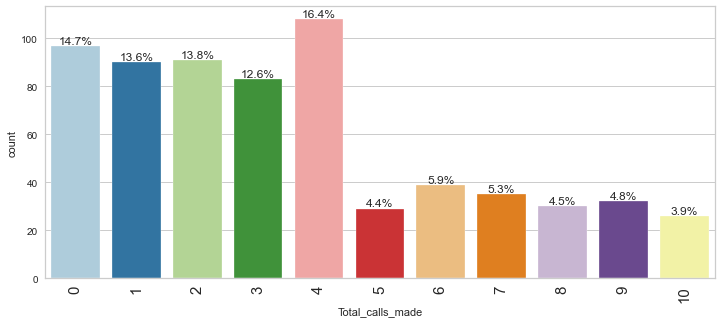

```python
# let's explore discounts further
labeled_barplot(df, "Total_calls_made", perc=True)
```

##### Observations

- 30% of customers made more than 5 times calls to bank per year.
- Same analysis should perform like how I discuss with customers online visits feature.